# Diabetes EDA

Martyna Majchrzak

31 03 2021

### Data distribution

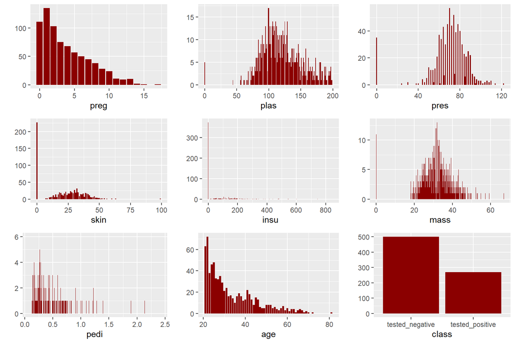

```r
library(ggplot2)
library(gridExtra)
variables <- names(diabetes)

plots <- lapply(variables, function(variable){
  ggplot(data=diabetes, aes_string(variable)) +
    geom_bar(fill='darkred') +
    ylab('')
})

grid.arrange(grobs=plots, ncol=3)
```

The classes ‘tested_negative’ and ‘tested positive’ are unballanced, the first one beeing around twice as big as the latter.

The variables `preg` and `age` have simmilar distributions, which makes sense, as an older women is more likely to have been pregant more times.

As we can see, the variables `plas`, `pres`, `skin`, `insu` and `mass` contain 0 values that are clearly outliers. We have the right to suspect that those are hidden outliers.

### Visualisation of missing data

Let’s assume that in all variables accept `preg`(where those are logically justified) value 0 is a missing data. Let’s visualize how many missing values are there in the dataset.

```r
diabetes_NA<-diabetes
diabetes_NA[diabetes_NA == 0] <- NA
diabetes_NA$preg[is.na(diabetes_NA$preg)] <- 0
```

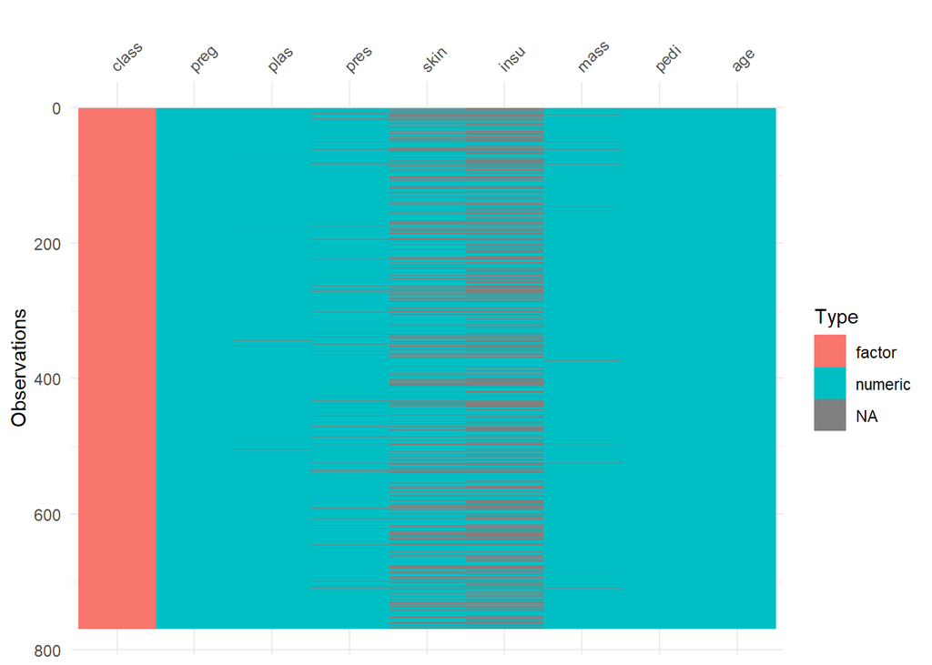

```r
visdat::vis_dat(diabetes_NA)
```

```r
knitr::kable(naniar::miss_var_summary(diabetes_NA), caption = "Procent of missing in dataset")
```

Procent of missing in dataset

| variable | n_miss | pct_miss |
| --- | --- | --- |
| insu | 374 | 48.6979167 |
| skin | 227 | 29.5572917 |
| pres | 35 | 4.5572917 |
| mass | 11 | 1.4322917 |
| plas | 5 | 0.6510417 |
| preg | 0 | 0.0000000 |
| pedi | 0 | 0.0000000 |
| age | 0 | 0.0000000 |
| class | 0 | 0.0000000 |